# ★코드_1. 딥러닝개요

### [1] 딥러닝개요

- 비정형데이터는 자료의 특징값만 반응하는 부분만 필터링하는 CNN(합성곱신경망) 작업을 거친후---> CNN이 있으면 딥러닝이라고함
- 가로*세로의 자료를 일렬로 쭉 나열하여서 x변수로 만드는 flatten 작업을 하여서 w,b를 생성함.
- 인공신경망 초반에는 모든 자료를 일렬로 나열했으나 특징이 사라져서 CNN모델로서 특징을 추출한뒤 flatten 하여서 w와 b값을 생성함

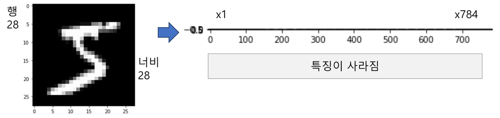

### [1-1] CNN(Convolutional neural network)

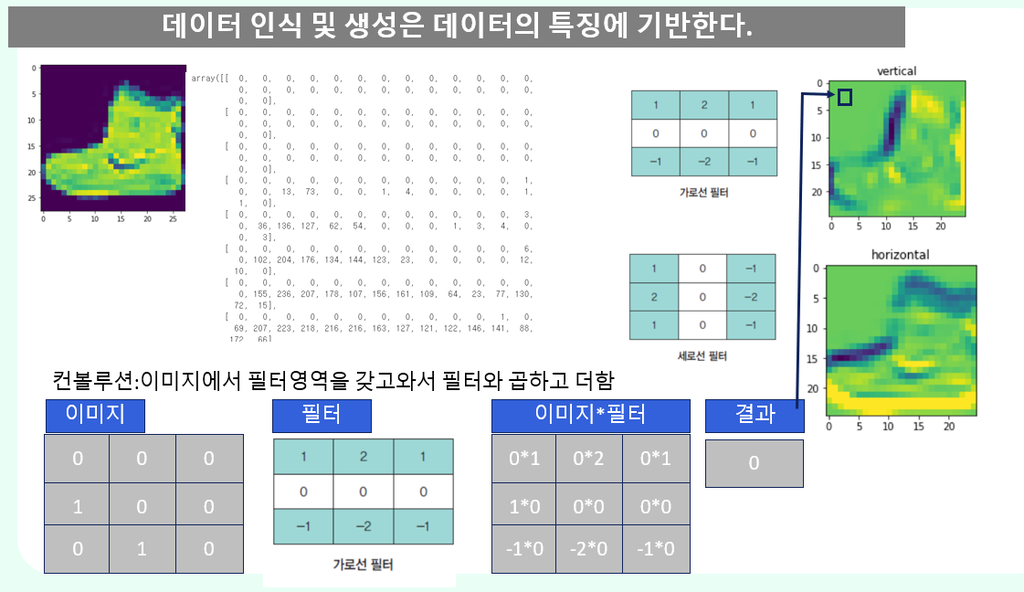

### [1-2] 텐서플로우 CNN 코드 샘플

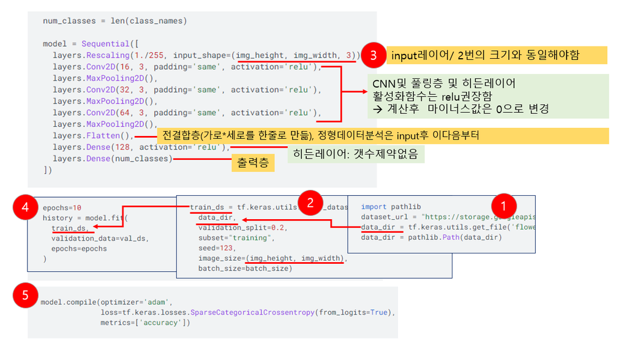

- ### [1-3] 지도학습: feature(input,x,독립변수)값과 label(output,y,종속변수, 클래스명)값이 있음

### 가장아래쪽 출력층 레이어의 계산식(활성화함수는) 레이블에 따라 약 3가지로 정해져 있음

  - - 레이블이 무한대의 숫자중 한개값이라면
      - [1] wx+wx+wx+...+b로 회귀분석이 됨. (무한대의 숫자값 한개가 출력됨)
    - **레이블이 0-1 의 사이값에서 출력되는 한개의 값이라면**
      - [1]번작업 회귀분석후 [2] sigmoid 수학식으로 최종 계산해야함.

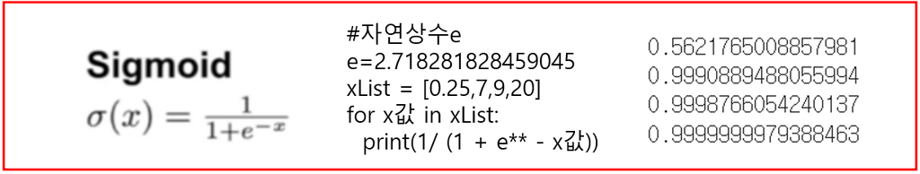

      - 예) 생사여부(0또는1) / 합격여부(0또는1) / 남여(0또는1)
      - 인공지능최종결과는 0또는1 로 출력되지 않고 0.3 / 0.2 / 0.7 등 0~1사이의 값으로 출력됨
      - 사용자가 임계값(보통 0.5)을 지정해서 최종 출력값에 예측값>0.5 크면 1 이런식으로 프로그래밍 해야함
      - 하지만 0이 생존인지, 사망인지는 알수 없음.
      - 프로그램에서 0, 1을 사망, 생존으로 지정해야함
    - **레이블이 2개이상의 경우일때 출력값이 [yes,no] 또는 [검정, 파랑, 빨강]등 여러 개중 한개에 해당하는 경우는**
      - [1] 번작업 회귀분석후 [2] sigmoid 수학식으로 0~1사이로 계산후 [3] softmax 수학식으로 최종 계산해야함

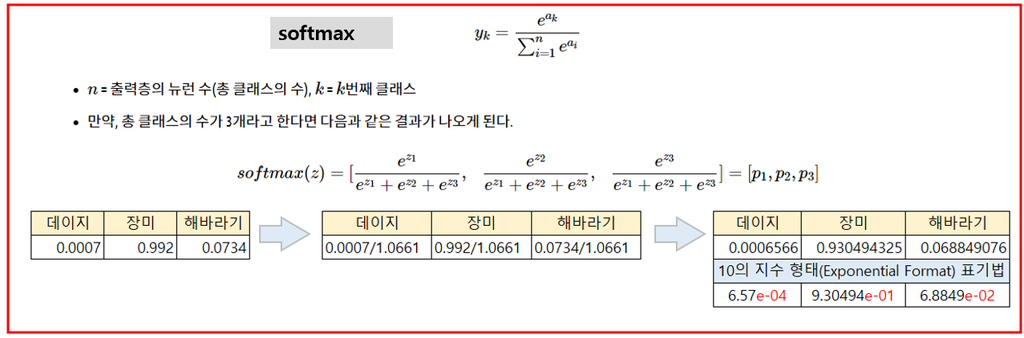

      - 인공지능 최종결과는 확률값으로만 출력됨으로 가장큰값을 갖고있는 위치값이 결과값이 됨
      - 위의경우는 [0번위치(데이지), 1번위치(장미), 2번위치(해바라기)] 중 1번위치의 값이 가장 큰값임을 알수있는
      - np.argmax함수를 이용하여서 큰값의 위치를 알아낼수 있으나 이 값이 '장미'임을 알수는 없음.
      - 레이블이름(클래스이름)변수를 별도로 갖고 있어야함
      - class_names[np.argmax(model.predict(new_img)))

```
- (참고) 비지도학습: feature(input,x)값만 있음 (강화학습, GAN과 같은 생성망)
```

- ### [1-4] 날코딩으로 인공신경망에 필수요소인 용어이해하기
- https://github.com/rickiepark/do-it-dl/blob/master/Ch03.ipynb
- 배치와 에포크 단위로 오차를 갱신함. (배치가 작을수록, 에포크가 많을수록 오차역전파는 많이 발생함)
  - x값에 w값을 연산한후(순전파) 실제값과의 차이를 계산, 이때 배치사이즈만큼 오차평균을 계산함
  - 계산된 오차값을 0으로 최소화하기 위한 경사하강을 진행하고 오차(err)를 이용하여 w,b를 갱신함.
  - 이때 w,b의 갱신율을 Learning rate 값을 이용하여 조정할수 있음. lr값이 작으면 작을수록 오차갱신폭이 작아짐
    - https://honeyjamtech.tistory.com/43
  - 갱신된 w,b를 다시 x데이터에 연산함(오차역전파)

```python
!pip install scikit-learn
```

```python
# 사이킷런에서 제공하는 당뇨병데이터셋 샘플 (x값한개 넣기위한 작업임, 의미없음)
from sklearn.datasets import load_diabetes
import numpy as np
diabetes = load_diabetes()

# 한개의 x값을 갖는 인공신경망을 만들기위하여 임의로 3번째의 변수를 x값으로 할당함, 3번째변수 의미없는 값임
x = diabetes.data[:, 2]
y = diabetes.target

np.shape(x), np.shape(y)  # x,y 데이터갯수 같아야함.
```

```
((442,), (442,))
```

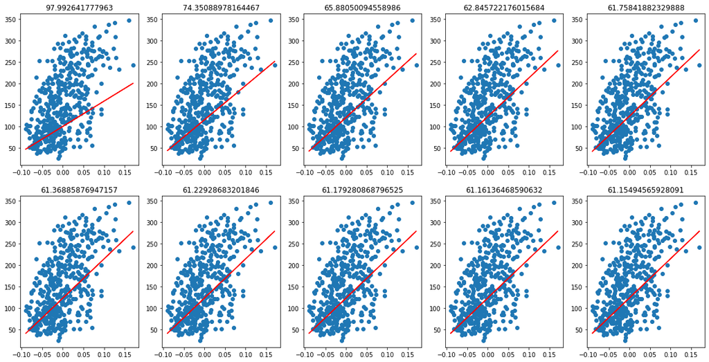

```python
class Neuron:

    def __init__(self):
        self.w = 1.0     # 가중치를 초기화합니다
        self.b = 1.0     # 절편을 초기화합니다
        self.lr=1

    def forpass(self, x):
        y_hat = x * self.w + self.b       # 직선 방정식을 계산합니다
        return y_hat

    def backprop(self, x, err):
        w_grad = x * err    # 가중치에 대한 그래디언트를 계산합니다
        b_grad = 1 * err  # 절편에 대한 그래디언트를 계산합니다
        return w_grad, b_grad

    def fit(self, x, y, epochs=10):
        plt.figure(figsize=(20,10))  # 그래프 사이즈

        for i in range(epochs):           # 에포크만큼 반복합니다

            for x_i, y_i in zip(x, y):    # 배치 1
                y_hat = self.forpass(x_i) # 정방향 계산
                err = -(y_i - y_hat)      # 오차 계산
                w_grad, b_grad = self.backprop(x_i, err)  # 역방향 계산
                self.w -= w_grad *self.lr        # 가중치 업데이트
                self.b -= b_grad *self.lr         # 절편 업데이트

            plt.subplot(int(epochs/5),5,i+1)
            plt.scatter(x,y)
            plt.plot(x,x*self.w+self.b, 'r')
            plt.title(err)
            #plt.show()
neuron = Neuron()
neuron.fit(x, y)
```

##### (참고) 더 복잡한 날코딩은 아래에서 확인

- https://github.com/rickiepark/do-it-dl/blob/master/Ch05.ipynb
- 경사하강법 및 오차역전파의 이해는 [day2 - 02.딥러닝기초.pptx 의 18p의 영상링크 확인]

### [1-5] 정형데이터를 이용한 CNN제외한 인공신경망 이해하기

- 이 자료의 목적 (파라미터의 이해)
- **[day2 - 03.파라미터와히든레이어_relu함수.pptx]**
- 순차형 모델 https://www.tensorflow.org/guide/keras/sequential_model?hl=ko

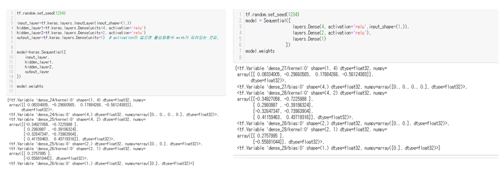

- 함수형 모델 https://www.tensorflow.org/guide/keras/functional?hl=ko

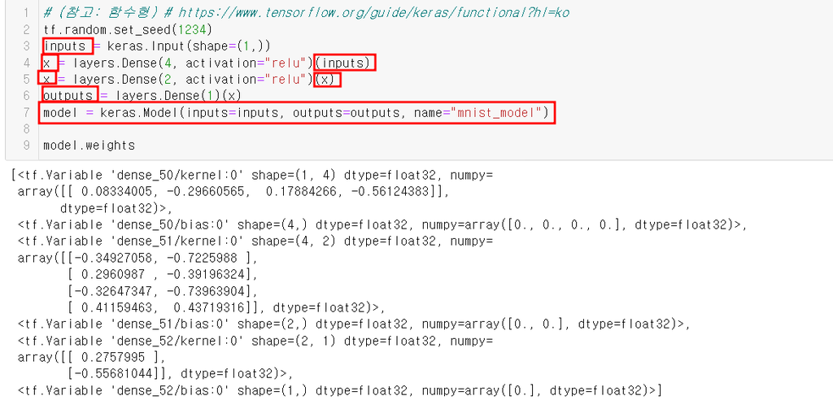

```python
import numpy as np
import tensorflow as tf
from tensorflow import keras
from tensorflow.keras import layers,Sequential
x=np.array([1,2,3,4,5,6])
y=np.array([10,98,8,2,3,4])   # y값은 무작위의 한개값이 예측되어야 함으로 회귀분석임
```

```python
tf.random.set_seed(1234)   # w값을 확인하기 위하여서임. 실제작업에서는 seed고정하지 않음.


input_layer=tf.keras.layers.InputLayer(input_shape=(1,))
hidden_layer1=tf.keras.layers.Dense(units=4, activation='relu')
hidden_layer2=tf.keras.layers.Dense(units=2, activation='relu')
output_layer=tf.keras.layers.Dense(units=1)  # activation이 없으면 활성화함수 wx+b가 되어있는 것임.


model=keras.Sequential([
    input_layer,
    hidden_layer1,
    hidden_layer2,
    output_layer
])

model.summary()

model.compile(optimizer='adam',
              loss='mse',
              metrics=['accuracy'])
print(model.fit(x,y))
print(model.predict(x))
print(model.evaluate(x,y))
```

```
Model: "sequential_7"
_________________________________________________________________
Layer (type)                 Output Shape              Param #
=================================================================
dense_21 (Dense)             (None, 4)                 8
_________________________________________________________________
dense_22 (Dense)             (None, 2)                 10
_________________________________________________________________
dense_23 (Dense)             (None, 1)                 3
=================================================================
Total params: 21
Trainable params: 21
Non-trainable params: 0
_________________________________________________________________
<keras.callbacks.History object at 0x000002C9A02C2580>
WARNING:tensorflow:5 out of the last 9 calls to <function Model.make_predict_function.<locals>.predict_function at 0x000002C99F1D7550> triggered tf.function retracing. Tracing is expensive and the excessive number of tracings could be due to (1) creating @tf.function repeatedly in a loop, (2) passin…
[[0.001]
 [0.001]
 [0.001]
 [0.001]
 [0.001]
 [0.001]]
[1632.7916259765625, 0.0]
```

```python
model.weights       # x변수가 1개, w가 기본1개임, b가1개임 wx+b임, units=4임으로 w값이 4개임
```

```
[<tf.Variable 'dense_21/kernel:0' shape=(1, 4) dtype=float32, numpy=
 array([[ 0.08334005, -0.29660565,  0.17884266, -0.56124383]],
       dtype=float32)>,
 <tf.Variable 'dense_21/bias:0' shape=(4,) dtype=float32, numpy=array([0., 0., 0., 0.], dtype=float32)>,
 <tf.Variable 'dense_22/kernel:0' shape=(4, 2) dtype=float32, numpy=
 array([[-0.34927058, -0.7225988 ],
        [ 0.2960987 , -0.39196324],
        [-0.32647347, -0.73963904],
        [ 0.41159463,  0.43719316]], dtype=float32)>,
 <tf.Variable 'dense_22/bias:0' shape=(2,) dtype=float32, numpy=array([0., 0.], dtype=float32)>,
 <tf.Variable 'dense_23/kernel:0' shape=(2, 1) dtype=float32, numpy=
 array([[ 0.2757995 ],
        [-0.55681044]], dtype=float32)>,
 <tf.Variable 'dense_23/bias:0' shape=(1,) dtype=float32, numpy=array([0.001], dtype=float32)>]
```

```python
for x in model.weights:
    print(x.shape)
```

```
(1, 4)
(4,)
(4, 2)
(2,)
(2, 1)
(1,)
```

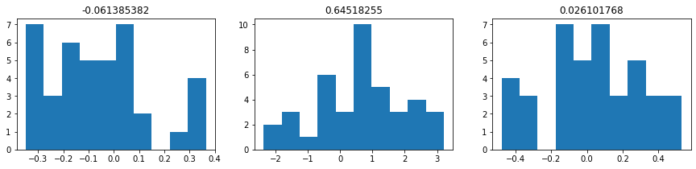

```python
## 참고 https://justweon-dev.tistory.com/43
modelA=Sequential([
  layers.Dense(40,activation='relu', input_shape=(1,))
])

modelB=Sequential([
   layers.Dense(40,activation='relu', kernel_initializer='he_normal',input_shape=(1,))

])

he_avg_init = keras.initializers.VarianceScaling(scale=2., mode='fan_avg', distribution='uniform')
modelC=Sequential([

    layers.Dense(40,activation='relu', kernel_initializer=he_avg_init,input_shape=(1,))
])

a=modelA.weights
b=modelB.weights
c=modelC.weights

plt.figure(figsize=(15,3))
plt.subplot(1,3,1)
plt.hist(a[0][0].numpy())
plt.title(a[0][0].numpy().mean())

plt.subplot(1,3,2)
plt.hist(b[0][0].numpy())
plt.title(b[0][0].numpy().mean())

plt.subplot(1,3,3)
plt.hist(c[0][0].numpy())
plt.title(c[0][0].numpy().mean())
```

```python
# 03.파라미터와히든레이어_relu함수.pptx 의 슬라이드 3번
intermediate_layer_model=tf.keras.Model(inputs=model.input, outputs=model.layers[0].output)
intermediate_output=intermediate_layer_model(x)
intermediate_output
```

[output not shown]

```python
# 03.파라미터와히든레이어_relu함수.pptx 의 슬라이드 4번
intermediate_layer_model=tf.keras.Model(inputs=model.input, outputs=model.layers[1].output)
intermediate_output=intermediate_layer_model(x)
intermediate_output
```

[output not shown]

```python
# 03.파라미터와히든레이어_relu함수.pptx 의 슬라이드 5번
intermediate_layer_model=tf.keras.Model(inputs=model.input, outputs=model.layers[2].output)
intermediate_output=intermediate_layer_model(x)
intermediate_output
```

[output not shown]

```python
model.predict(x)
```

[output not shown]

```python
newData=[3]
model.predict(newData)
```

```
array([[0.001]], dtype=float32)
```